# Assignment 1

## Load Data

The dataset I used contains NBA player statistics for the 2025-2026 season. I obtained it from Basketball Reference. It contains both categorical and quantitative variables.

```r
library(readr)

nba <- read_csv("Downloads/Untitled spreadsheet - Sheet1.csv")
```

## View data

I used the head function to view the first six observations in the data to be sure the data was imported correctly. It also showed me an overview of the variables I would be using in my analysis.

```r
head(nba)
```

```
## # A tibble: 6 × 32
##      Rk Player   Age Team  Pos       G    GS    MP    FG   FGA `FG%`  `3P` `3PA`
##   <dbl> <chr>  <dbl> <chr> <chr> <dbl> <dbl> <dbl> <dbl> <dbl> <dbl> <dbl> <dbl>
## 1     1 Luka …    26 LAL   PG       64    64  35.8  10.8  22.8 0.476   4    10.8
## 2     2 Shai …    27 OKC   PG       68    68  33.2  10.8  19.4 0.553   1.7   4.4
## 3     3 Antho…    24 MIN   SG       61    60  35     9.9  20.2 0.489   3.4   8.4
## 4     4 Jayle…    29 BOS   SF       71    71  34.4  10.4  21.7 0.477   2     5.7
## 5     5 Tyres…    25 PHI   PG       70    70  38     9.9  21.4 0.462   3.1   8.6
## 6     6 Kawhi…    34 LAC   SF       65    65  32.1   9.8  19.4 0.505   2.6   6.8
## # ℹ 19 more variables: `3P%` <dbl>, `2P` <dbl>, `2PA` <dbl>, `2P%` <dbl>,
## #   `eFG%` <dbl>, FT <dbl>, FTA <dbl>, `FT%` <dbl>, ORB <dbl>, DRB <dbl>,
## #   TRB <dbl>, AST <dbl>, STL <dbl>, BLK <dbl>, TOV <dbl>, PF <dbl>, PTS <dbl>,
## #   Awards <chr>, `Player-additional` <chr>
```

## Descriptive Statistics (Quantitative Variables)

The summary statistics provided are of three quantitative variables. I chose to do points per game (PTS), assists per game (AST), and total rebounds per game (TRB). The summaries of these variables provide information on the minimum, first quarter, median, mean, third quarter, and maximum values.

```r
summary(nba$PTS)
```

```
##    Min. 1st Qu.  Median    Mean 3rd Qu.    Max.     NAs
##    0.00    4.10    7.50    8.89   12.20   33.50       1
```

```r
summary(nba$AST)
```

```
##    Min. 1st Qu.  Median    Mean 3rd Qu.    Max.     NAs
##   0.000   0.800   1.600   2.096   2.800  10.700       1
```

```r
summary(nba$TRB)
```

```
##    Min. 1st Qu.  Median    Mean 3rd Qu.    Max.     NAs
##   0.000   1.800   3.000   3.452   4.700  12.900       1
```

## Descriptive Statistics (Categorical Variables)

The two frequency tables provide information on the two categorical variables of player position and team. The two tables show the distribution of players across the 5 positions in basketball and the 30 teams.

```r
table(nba$Pos)
```

```
##
##   C  PF  PG  SF  SG
## 144 121 130 133 205
```

```r
table(nba$Team)
```

```
##
## 2TM 3TM 4TM ATL BOS BRK CHI CHO CLE DAL DEN DET GSW HOU IND LAC LAL MEM MIA MIL
##  66   5   1  25  21  22  28  21  24  23  19  20  22  16  27  26  20  33  17  21
## MIN NOP NYK OKC ORL PHI PHO POR SAC SAS TOR UTA WAS
##  21  19  20  20  19  23  20  20  23  20  20  25  26
```

## Variable Transformation

Assist to turnover ration (AST_TOV) variable made by dividing assists per game by turnovers per game, measures players efficiency in creating assists while limiting turnovers.

```r
nba$AST_TOV <- nba$AST / nba$TOV
head(nba$AST_TOV)
```

```
## [1] 2.075000 3.000000 1.275862 1.416667 2.750000 1.800000
```

## Histogram

This histogram shows the distribution of points per game for all NBA players. Most of the players in the league scored between 0 and 10 points, whereas a very small percentage scored above 25 points per game. This is as expected.

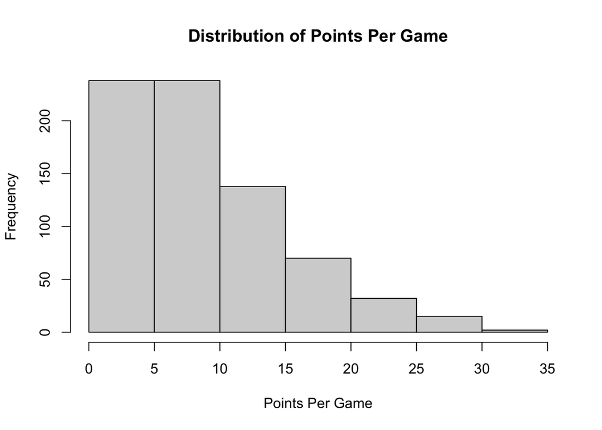

```r
hist(nba$PTS,
     main = "Distribution of Points Per Game",
     xlab = "Points Per Game")
```

## Scatterplot

The scatterplot shows the relationship between assists per game and points per game. The plot suggests a positive relationship with players who average a higher number of assists also average more points per game. However, most players average a low number of assists and points per game still.

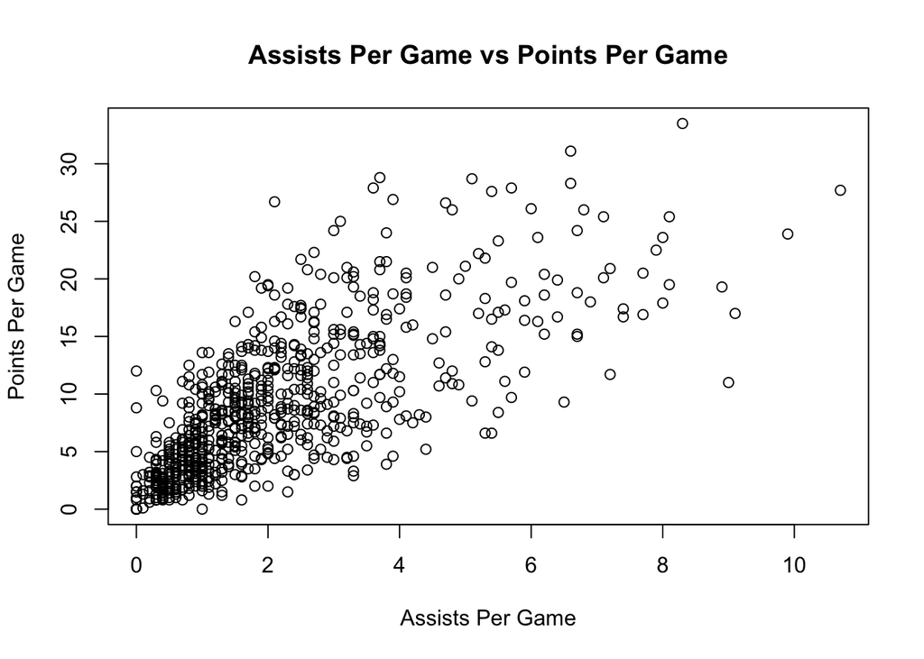

```r
plot (nba$AST,
      nba$PTS,
      main = "Assists Per Game vs Points Per Game",
      xlab = "Assists Per Game",
      ylab = "Points Per Game")
```